# Hidden Fabricated Data in Synthetic Data: A Cautionary Example

Andrew J. Kelly

6/13/2021

### Code

[Github](https://github.com/AndJKel/blog-scripts/blob/main/Hidden%20Fabricated%20Data%20in%20Synthetic%20Data%20-%20A%20Cautionary%20Example.R)

### An Experimental Failure: A Hypothetical Scenario

Let’s say that you are an intervention researcher and you work in reducing blood pressure. You recently read an updated meta-analysis which states that salt intake does significantly influence blood pressure. You’ve also recently read an article over the potential benefit which personal narratives can have in influencing patient decision making. An experiment is now in order.

Unfortunately, the result isn’t significant. Even if it was, however, it wouldn’t be relevant (*d* = 0.07) as the effect is incredibly small.

### A Way Out

Data and research falsification is a thing, this really isn’t up for debate. The best estimates right now are bad for prevalence, but I think Bik’s estimate[1] of <4% is fair. That said, perhaps there is a reason (*ahem, publish-or-perish*) you **must** publish the results. You do what you believe you need to, you alter the data, but not enough to make it questionable.

It is now a publishable result, with a large effect. The intervention also isn’t inherently eye-opening[2]

### Now, to Hide the Evidence

Lucky for you, the research you did has some protections - especially if you collected some irrelevant data which involves a clinical measure (e.g., blood pressure). You have an immediate defense if someone began to poke around your results and wanted a data file. But… what if you wanted to prevent someone from poking around at all?

Here, synthetic data is very useful. An `R` package I am a fan of called `synthpop` can produce a *potentially* valid dataset in only a few lines of code:

`synthetic_data <- syn(dataframe, seed = 1234)`

`synthetic_dataframe <- synthetic_data$syn`

After creating the synthetic dataset, you must do the two checks necessary to see if it is a **valid** dataset. First, do the distribution of values look similar?

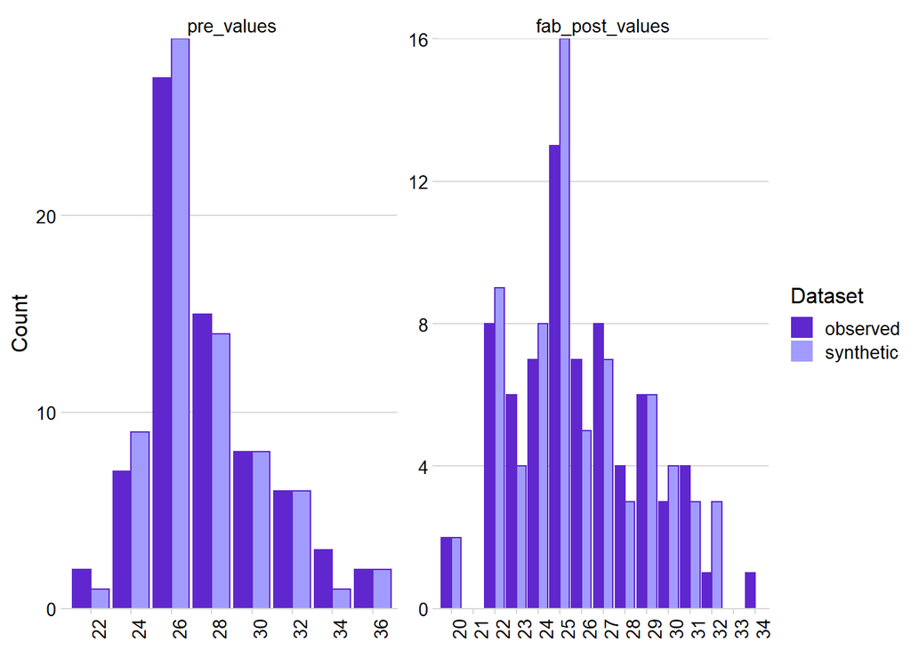

Yes, the distribution of values looks the same for the observed and synthetic dataset.

Congratulations, you now have a synthetic dataset to mention is available in a manuscript!

### Main Takeaways?

Synthetic data can be useful, but it can also be used maliciously. Original, source data is all you should even begin to trust - even then, question it.

### Notes

[1] https://doi.org/10.1128/mBio.00809-16

[2] I have no idea what the average effect size would be, but this does not immediately raise my “How?” button.